# Thought Starter Visuals

# Assignment04 Charts

## Variable Width Column Chart

# Using mekko package

1. Load package
2. Create data (from cereal dataset)
3. Plot https://rdrr.io/cran/mekko/man/barmekko.html
4. Final edits -remove x ticks and titles with element_blank (https://stackoverflow.com/questions/35090883/remove-all-of-x-axis-labels-in-ggplot)
- add titles
- change font to Times New Roman

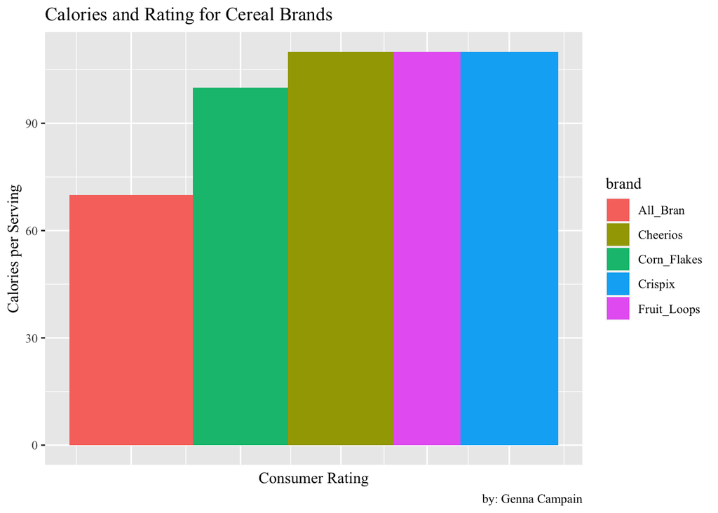

```r
library(mekko)
library(ggplot2)

nutritioninfo <- data.frame(
  brand = c('All_Bran', 'Corn_Flakes', 'Cheerios', 'Fruit_Loops', 'Crispix'),
  calories = c(70, 100, 110, 110, 110),
  rating = c(59.4, 45.9, 50.8, 32.2, 46.9)
)

barmekko(nutritioninfo, brand, calories, rating) +
  theme(axis.ticks.x = element_blank(), axis.text.x = element_blank()) + labs(x = "Consumer Rating", y = "Calories per Serving", title = "Calories and Rating for Cereal Brands", caption = "by: Genna Campain") + theme(text= element_text(family = "Times New Roman"))
```

## Bar Chart

Use stat = identity to indicate that I will be giving the values for the y axis (otherwise R wants to calculate them) Rotate whole chart

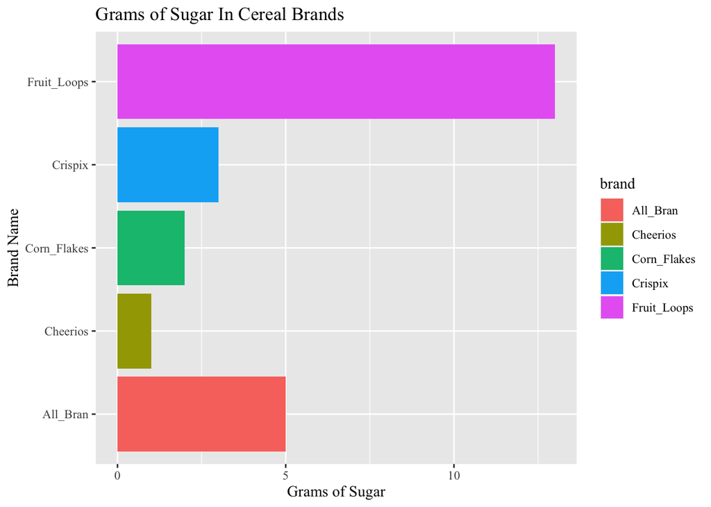

```r
library(ggplot2)

sugarsinfo <- data.frame(
  brand = c('All_Bran', 'Corn_Flakes', 'Cheerios', 'Fruit_Loops', 'Crispix'),
  sugars = c(5, 2, 1, 13, 3)
)

p <-ggplot(data = sugarsinfo, mapping = aes(x = brand, y = sugars, fill = brand))
p + geom_bar(stat = 'identity') +
  labs(x = "Brand Name", y = "Grams of Sugar", title = "Grams of Sugar In Cereal Brands") +
  theme(text = element_text(family = "Times New Roman")) +
  coord_flip()
```

## Column Chart

Need to change data format to long using tidyr package Use position argument to create bars that are next to each other

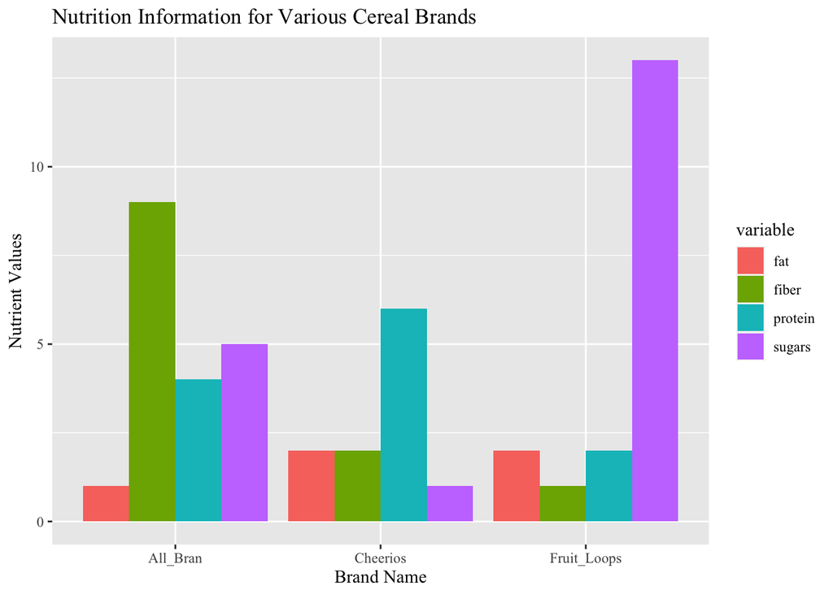

```r
library(ggplot2)

nutrition <- data.frame(
  newbrand = c("All_Bran", "Cheerios", "Fruit_Loops"),
  sugars = c(5, 1, 13),
  protein = c(4, 6, 2),
  fat = c(1, 2, 2),
  fiber = c(9, 2, 1)
)

library(tidyr)
nutrition_long <- gather(nutrition, variable, nutrients, -newbrand )

p <- ggplot(nutrition_long, mapping = aes(x = newbrand, y = nutrients, fill = variable))
p + geom_col(position = position_dodge()) +
  labs(x = "Brand Name", y = "Nutrient Values", title = "Nutrition Information for Various Cereal Brands") +
  theme(text = element_text(family = "Times New Roman"))
```

## Table (with Embedded Charts)

Use formattable package to make more create tables (https://renkun-ken.github.io/formattable/)

```r
library(formattable)
cereal <- read.csv("~/Downloads/cereal.csv")

df <- data.frame(
  name = cereal$name,
  calories = cereal$calories,
  protein = cereal$protein,
  fat = cereal$fat,
  fiber = cereal$fiber,
  rating = cereal$rating
)

formattable(df, list(area(col = c(fiber))~normalize_bar("pink", 0.2)))
```

| name | calories | protein | fat | fiber | rating |
| --- | --- | --- | --- | --- | --- |
| 100% Bran | 70 | 4 | 1 | 10.0 | 68.40297 |
| 100% Natural Bran | 120 | 3 | 5 | 2.0 | 33.98368 |
| All-Bran | 70 | 4 | 1 | 9.0 | 59.42551 |
| All-Bran with Extra Fiber | 50 | 4 | 0 | 14.0 | 93.70491 |
| Almond Delight | 110 | 2 | 2 | 1.0 | 34.38484 |
| Apple Cinnamon Cheerios | 110 | 2 | 2 | 1.5 | 29.50954 |
| Apple Jacks | 110 | 2 | 0 | 1.0 | 33.17409 |
| Basic 4 | 130 | 3 | 2 | 2.0 | 37.03856 |
| Bran Chex | 90 | 2 | 1 | 4.0 | 49.12025 |
| Bran Flakes | 90 | 3 | 0 | 5.0 | 53.31381 |
| Cap’n’Crunch | 120 | 1 | 2 | 0.0 | 18.04285 |
| Cheerios | 110 | 6 | 2 | 2.0 | 50.76500 |
| Cinnamon Toast Crunch | 120 | 1 | 3 | 0.0 | 19.82357 |
| Clusters | 110 | 3 | 2 | 2.0 | 40.40021 |
| Cocoa Puffs | 110 | 1 | 1 | 0.0 | 22.73645 |
| Corn Chex | 110 | 2 | 0 | 0.0 | 41.44502 |
| Corn Flakes | 100 | 2 | 0 | 1.0 | 45.86332 |
| Corn Pops | 110 | 1 | 0 | 1.0 | 35.78279 |
| Count Chocula | 110 | 1 | 1 | 0.0 | 22.39651 |
| Cracklin’ Oat Bran | 110 | 3 | 3 | 4.0 | 40.44877 |
| Cream of Wheat (Quick) | 100 | 3 | 0 | 1.0 | 64.53382 |
| Crispix | 110 | 2 | 0 | 1.0 | 46.89564 |
| Crispy Wheat & Raisins | 100 | 2 | 1 | 2.0 | 36.17620 |
| Double Chex | 100 | 2 | 0 | 1.0 | 44.33086 |
| Froot Loops | 110 | 2 | 1 | 1.0 | 32.20758 |
| Frosted Flakes | 110 | 1 | 0 | 1.0 | 31.43597 |
| Frosted Mini-Wheats | 100 | 3 | 0 | 3.0 | 58.34514 |
| Fruit & Fibre Dates; Walnuts; and Oats | 120 | 3 | 2 | 5.0 | 40.91705 |
| Fruitful Bran | 120 | 3 | 0 | 5.0 | 41.01549 |
| Fruity Pebbles | 110 | 1 | 1 | 0.0 | 28.02576 |
| Golden Crisp | 100 | 2 | 0 | 0.0 | 35.25244 |
| Golden Grahams | 110 | 1 | 1 | 0.0 | 23.80404 |
| Grape Nuts Flakes | 100 | 3 | 1 | 3.0 | 52.07690 |
| Grape-Nuts | 110 | 3 | 0 | 3.0 | 53.37101 |
| Great Grains Pecan | 120 | 3 | 3 | 3.0 | 45.81172 |
| Honey Graham Ohs | 120 | 1 | 2 | 1.0 | 21.87129 |
| Honey Nut Cheerios | 110 | 3 | 1 | 1.5 | 31.07222 |
| Honey-comb | 110 | 1 | 0 | 0.0 | 28.74241 |
| Just Right Crunchy Nuggets | 110 | 2 | 1 | 1.0 | 36.52368 |
| Just Right Fruit & Nut | 140 | 3 | 1 | 2.0 | 36.47151 |
| Kix | 110 | 2 | 1 | 0.0 | 39.24111 |
| Life | 100 | 4 | 2 | 2.0 | 45.32807 |
| Lucky Charms | 110 | 2 | 1 | 0.0 | 26.73451 |
| Maypo | 100 | 4 | 1 | 0.0 | 54.85092 |
| Muesli Raisins; Dates; & Almonds | 150 | 4 | 3 | 3.0 | 37.13686 |
| Muesli Raisins; Peaches; & Pecans | 150 | 4 | 3 | 3.0 | 34.13976 |
| Mueslix Crispy Blend | 160 | 3 | 2 | 3.0 | 30.31335 |
| Multi-Grain Cheerios | 100 | 2 | 1 | 2.0 | 40.10596 |
| Nut&Honey Crunch | 120 | 2 | 1 | 0.0 | 29.92429 |
| Nutri-Grain Almond-Raisin | 140 | 3 | 2 | 3.0 | 40.69232 |
| Nutri-grain Wheat | 90 | 3 | 0 | 3.0 | 59.64284 |
| Oatmeal Raisin Crisp | 130 | 3 | 2 | 1.5 | 30.45084 |
| Post Nat. Raisin Bran | 120 | 3 | 1 | 6.0 | 37.84059 |
| Product 19 | 100 | 3 | 0 | 1.0 | 41.50354 |
| Puffed Rice | 50 | 1 | 0 | 0.0 | 60.75611 |
| Puffed Wheat | 50 | 2 | 0 | 1.0 | 63.00565 |
| Quaker Oat Squares | 100 | 4 | 1 | 2.0 | 49.51187 |
| Quaker Oatmeal | 100 | 5 | 2 | 2.7 | 50.82839 |
| Raisin Bran | 120 | 3 | 1 | 5.0 | 39.25920 |
| Raisin Nut Bran | 100 | 3 | 2 | 2.5 | 39.70340 |
| Raisin Squares | 90 | 2 | 0 | 2.0 | 55.33314 |
| Rice Chex | 110 | 1 | 0 | 0.0 | 41.99893 |
| Rice Krispies | 110 | 2 | 0 | 0.0 | 40.56016 |
| Shredded Wheat | 80 | 2 | 0 | 3.0 | 68.23588 |
| Shredded Wheat ’n’Bran | 90 | 3 | 0 | 4.0 | 74.47295 |
| Shredded Wheat spoon size | 90 | 3 | 0 | 3.0 | 72.80179 |
| Smacks | 110 | 2 | 1 | 1.0 | 31.23005 |
| Special K | 110 | 6 | 0 | 1.0 | 53.13132 |
| Strawberry Fruit Wheats | 90 | 2 | 0 | 3.0 | 59.36399 |
| Total Corn Flakes | 110 | 2 | 1 | 0.0 | 38.83975 |
| Total Raisin Bran | 140 | 3 | 1 | 4.0 | 28.59278 |
| Total Whole Grain | 100 | 3 | 1 | 3.0 | 46.65884 |
| Triples | 110 | 2 | 1 | 0.0 | 39.10617 |
| Trix | 110 | 1 | 1 | 0.0 | 27.75330 |
| Wheat Chex | 100 | 3 | 1 | 3.0 | 49.78744 |
| Wheaties | 100 | 3 | 1 | 3.0 | 51.59219 |
| Wheaties Honey Gold | 110 | 2 | 1 | 1.0 | 36.18756 |

## Circular Area/Radar Chart

*Note: this chart type has come under fire lately for readability issues, it may be better to use lollipop charts instead (see https://www.data-to-viz.com/caveat/spider.html) Data format very important -each row is an entity -each column is a quantitative variable -the first two rows provide min/max value for the variable (5 values for x (max and min) and 0-10 range for y) “rgb” argument describes input for red, green, blue color values and transparency (1 = opaque) Reference https://www.rdocumentation.org/packages/fmsb/versions/0.7.0/topics/radarchart for more information

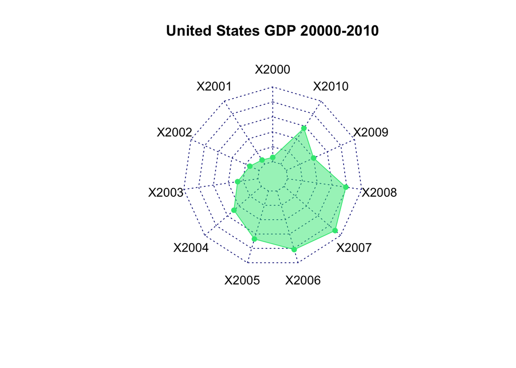

```r
library (fmsb)

data <- data.frame(
  "2000" = 28702,
  "2001" = 28726,
  "2002" = 28977,
  "2003" = 29459,
  "2004" = 30200,
  "2005" = 30842,
  "2006" = 31358,
  "2007" = 31655,
  "2008" = 31251,
  "2009" = 29899,
  "2010" = 30491
)
data <- rbind(rep(32000,10) , rep(28500, 10) , data)
radarchart(data ,
           pcol=(rgb(0.2,0.9,0.5,1.0)),
           pfcol=rgb(0.2,0.9,0.5,0.5) ,
           title = "United States GDP 20000-2010",
           seg = 5
           )
```

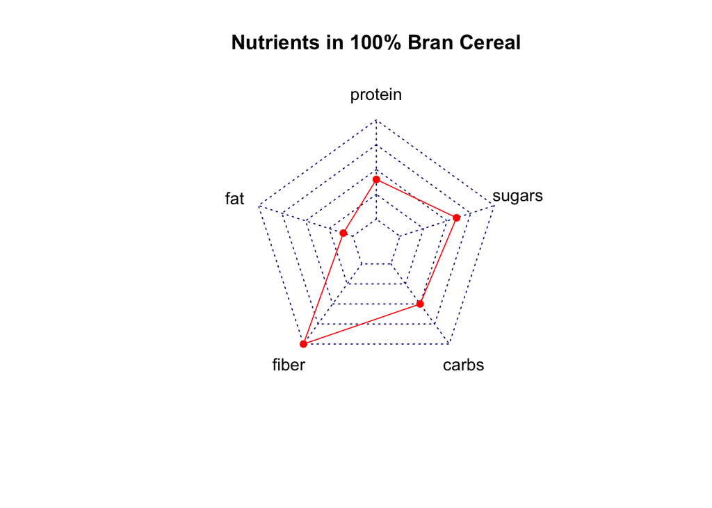

```r
data <- data.frame(
  protein = 4,
  fat = 1,
  fiber = 10,
  carbs = 5,
  sugars = 6
)
data <- rbind(rep(10, 5) , rep(0, 5) , data)
radarchart(data ,
           pcol="red",
           title = "Nutrients in 100% Bran Cereal"
           )
```

## Simple Line Chart

```r
library(tidyverse)
library(extrafont)
```

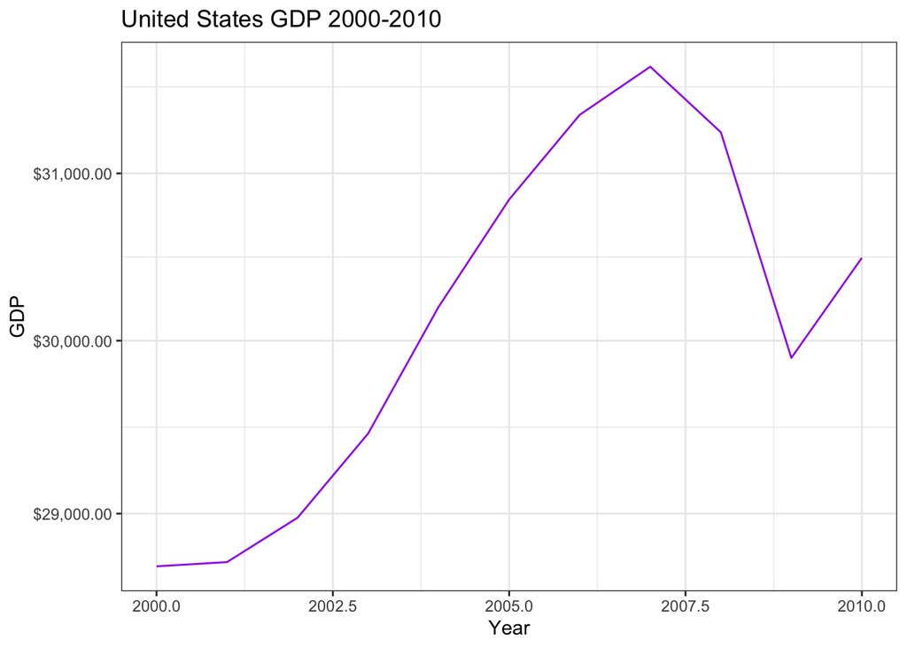

```r
data <- data.frame(
  year = c(2000, 2001, 2002, 2003, 2004, 2005, 2006, 2007, 2008, 2009, 2010),
  GDP = c(28702, 28726, 28977, 29459, 30200, 30842, 31358, 31655, 31251, 29899, 30491)
)

p <-ggplot(data, mapping = aes(x = year, y = GDP))
p + geom_line(color = "purple") +
  labs(x = "Year", y = "GDP", title = "United States GDP 2000-2010") +
  scale_y_log10(labels = scales::dollar) +
  theme(text = element_text(family = "Impact")) +
  theme_bw()
```

## Column Histogram

Changing axis labels: https://www.datanovia.com/en/blog/ggplot-axis-ticks-set-and-rotate-text-labels/ Center text using ggtitle to produce title and then theme with arguments to center

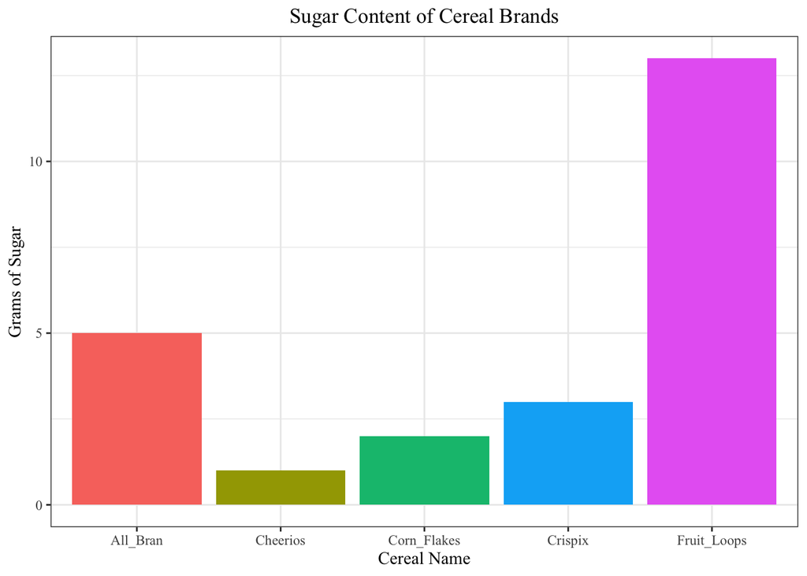

```r
library(tidyverse)
library(extrafont)

data <- data.frame(
  cerealname = c('All_Bran', 'Corn_Flakes', 'Cheerios', 'Fruit_Loops', 'Crispix'),
  sugars = c(5, 2, 1, 13, 3)
)

p <- ggplot(data, mapping = aes(x = cerealname, y = sugars, fill = cerealname))
p + geom_histogram(stat = 'identity') +
  theme(axis.text.x = element_text(angle = 90)) +
  theme_bw() +
  theme(text = element_text(family = "Times New Roman")) +
  labs(x = "Cereal Name", y = "Grams of Sugar") +
  theme(legend.position = "none") +
  ggtitle("Sugar Content of Cereal Brands") +
  theme(plot.title = element_text(hjust = 0.5))
```

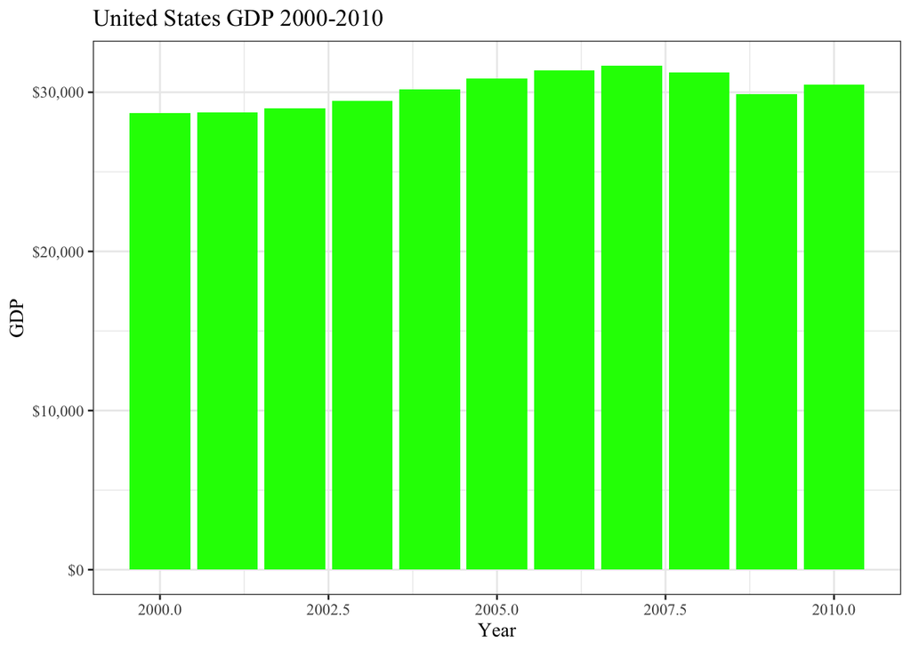

```r
data <- data.frame(
  year = c(2000, 2001, 2002, 2003, 2004, 2005, 2006, 2007, 2008, 2009, 2010),
  GDP = c(28702, 28726, 28977, 29459, 30200, 30842, 31358, 31655, 31251, 29899, 30491)
)
p <- ggplot(data, mapping = aes(x = year, y = GDP))
p + geom_histogram(stat = 'identity', fill = "green") +
  ggtitle("United States GDP 2000-2010") +
  theme(plot.title = element_text(hjust = 0.5)) +
  labs(x = "Year", y = "GDP") +
  scale_y_continuous(labels = scales::dollar) +
  theme_bw() +
  theme(text = element_text(family = "Times New Roman"))
```

## Line Histogram

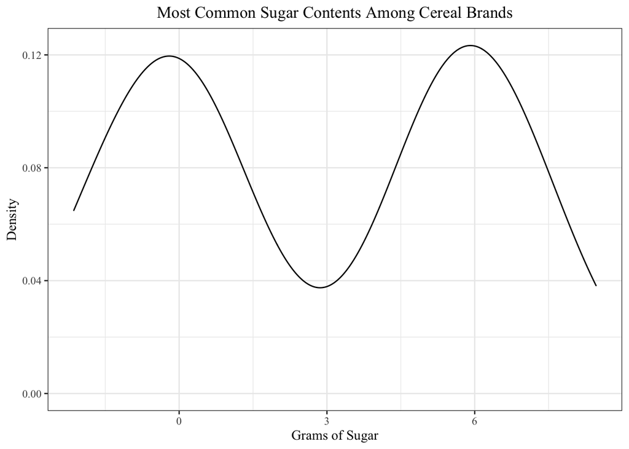

```r
library(tidyverse)

data <- data.frame(
  sugars = c(rnorm(40), rnorm(40, mean = 6))
)

p <- ggplot(data, mapping = aes(x = sugars))
p + geom_density() +
  theme(axis.text.x = element_text(angle = 90)) +
  theme_bw() +
  theme(text = element_text(family = "Times New Roman")) +
  labs(x = "Grams of Sugar", y = "Density") +
  theme(legend.position = "none") +
  ggtitle("Most Common Sugar Contents Among Cereal Brands") +
  theme(plot.title = element_text(hjust = 0.5))
```

## Scatter Chart

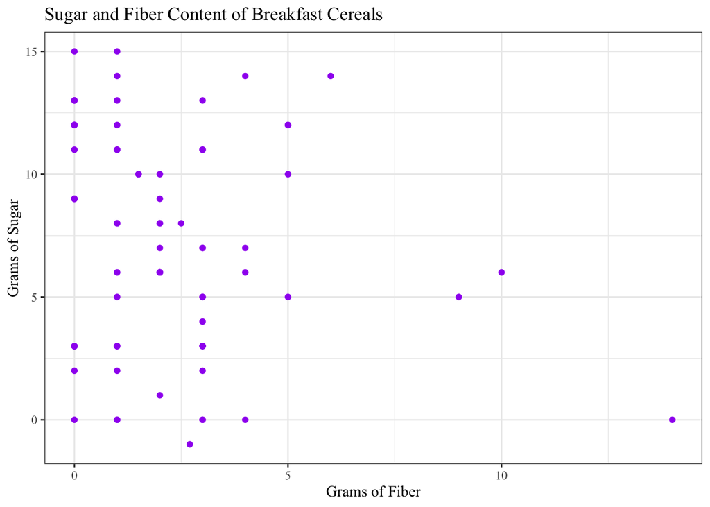

```r
library(tidyverse)

data <- data.frame(
  sugar = cereal$sugars,
  fiber = cereal$fiber
)

p <- ggplot(data, mapping = aes(x = fiber, y = sugar))
p + geom_point(color = "purple") +
  theme_bw() +
  labs(x = "Grams of Fiber", y = "Grams of Sugar", title = "Sugar and Fiber Content of Breakfast Cereals") +
  theme(text = element_text(family = "Times New Roman"))
```

## Stacked Column Chart with Subcomponents

Scaled to one; https://stackoverflow.com/questions/9563368/create-stacked-barplot-where-each-stack-is-scaled-to-sum-to-100

General chart including data formatting: https://www.datanovia.com/en/blog/how-to-create-a-ggplot-stacked-bar-chart-2/

Use fill argument to change label for map legend

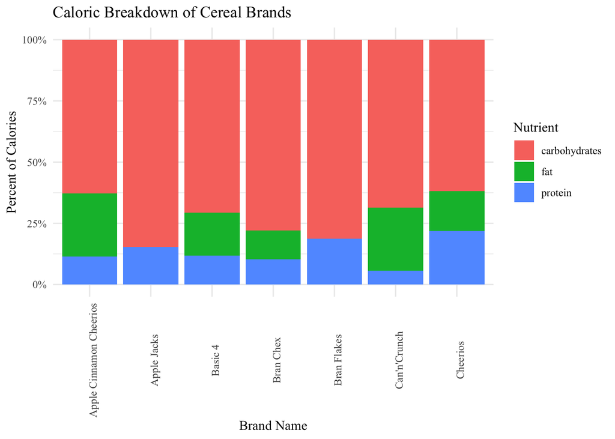

```r
library(tidyverse)

data <- data.frame(
  nutrient = rep(c("protein", "fat", "carbohydrates"), each = 7),
  cereal = c("Apple Cinnamon Cheerios", "Apple Jacks", "Basic 4", "Bran Chex", "Bran Flakes", "Can'n'Crunch", "Cheerios"),
  cals = c(8, 8, 12, 8, 12, 4, 24, 18, 0, 18, 9, 0, 18, 18,44, 44, 72, 60, 52, 48, 68 )
)
p <- ggplot(data, mapping = aes(x = cereal, y = cals, fill = nutrient))
p + geom_col(position = "fill", stat = "identity") +
  labs(x = "Brand Name", y = "Percent of Calories", title = "Caloric Breakdown of Cereal Brands", fill = "Nutrient") +
  theme_minimal() +
  theme(axis.text.x = element_text(angle = 90)) +
  scale_y_continuous(labels = scales::percent_format()) +
  theme(text = element_text(family = "Times New Roman"))
```

## 3D Area Chart